# Broome County Regression Analysis

Amber Jacobson

December 6, 2017

## Social Equity in Relation to Owner-Occupied Housing

#### In order to assess equity within the county, a number of variables from census information can be used to assess which factors are significant when it comes to a person’s ability to own a home. My hypothesis is that age, income, and education are the significant variables. In this analysis, multiple regression will be used to see the relevance of the selected variables.

## Part 1

#### Create a map of Broome County census tracts as well as a map of the level of owner-occupancy across the census tracts.

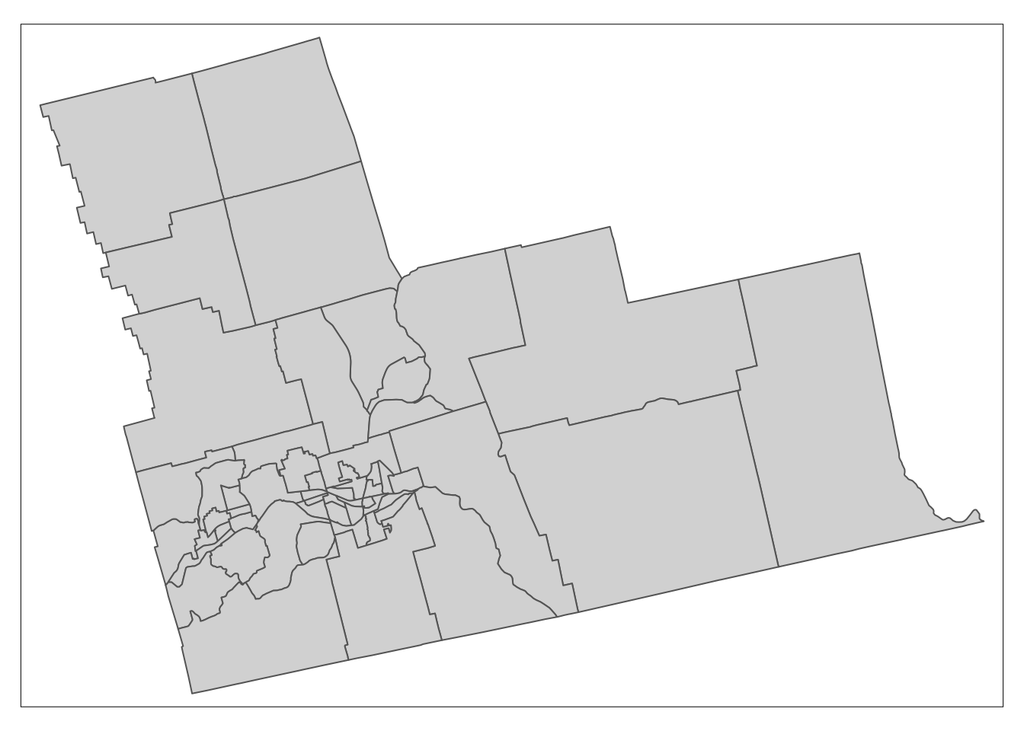

```r
library(rgdal)
Broome <- readOGR(".", "E")
df <- Broome@data

if(!require(tmap)) {install.packages("tmap")}
library(tmap)

qtm(Broome)
```

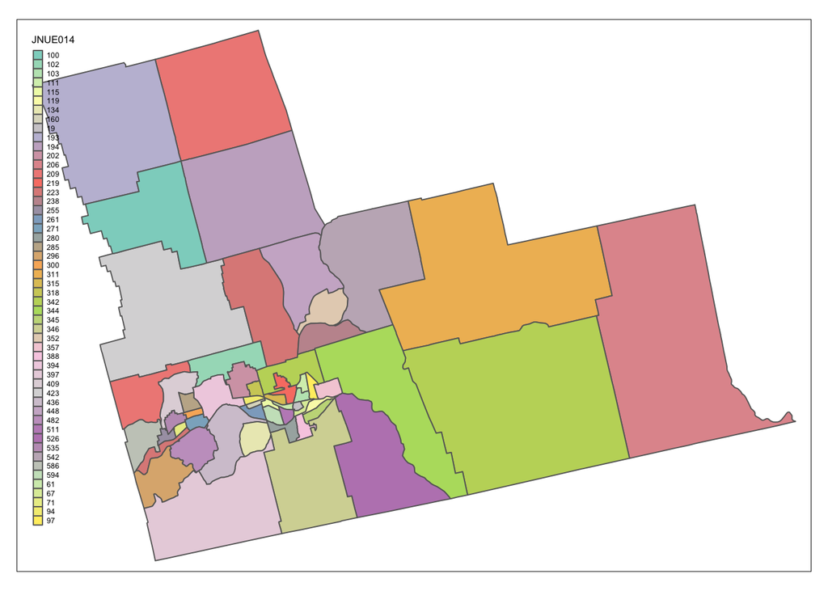

```r
qtm(Broome, fill="JNUE014")
```

The color scheme of the map makes it difficult to analyze where the concentration of owner-occupied housing is, but if the map is looked at carefully it is possible to identify that the lowest concentration of owner-occupied housing is in the more urban areas of the city of Binghamton and towns of Endicott and Johnson City.

## Part 2A

### First Regression

#### Perform a regression analysis using owner-occupied housing units as the dependent variable with age, income, and education attainment as independent variables.

```r
owner.occupied <- df$JNUE014
age <- df$JL0M001
income <- df$ADOVE001
education <- df$ADMZE001

bc <- cbind(owner.occupied,age,income,education)
colnames(bc) <- c("Owner Occupied", "Age", "Income", "Education")
x <- as.data.frame(bc)
m <- lm(x$`Owner Occupied` ~ x$Age + x$Income + x$Education)
anova(m)
```

```
## Analysis of Variance Table
##
## Response: x$`Owner Occupied`
##             Df Sum Sq Mean Sq F value   Pr(>F)
## x$Age        1   34.3   34.33  0.1841 0.669683
## x$Income     1  994.2  994.17  5.3315 0.025030 *
## x$Education  1 1434.9 1434.90  7.6951 0.007717 **
## Residuals   51 9509.9  186.47
## ---
## Signif. codes:  0 '***' 0.001 '**' 0.01 '*' 0.05 '.' 0.1 ' ' 1
```

Based off of the ANOVA table, education attainment and income are significant variables in relation to owner-occupied housing. The P-value of age is greater than .5, thus proving that it is not as useful in the regression. Age isn’t significant so this may be a weakness in the analysis and should perhaps be left out.

## Part 2B

### Perform a backwards regression analysis to confirm the variables that should be included in the final equation.

```r
m.reduced <- step(m, direction = "backward")
```

```
## Start:  AIC=291.4
## x$`Owner Occupied` ~ x$Age + x$Income + x$Education
##
##               Df Sum of Sq     RSS    AIC
## - x$Age        1    298.79  9808.7 291.10
## <none>                      9509.9 291.40
## - x$Income     1    477.62  9987.6 292.10
## - x$Education  1   1434.90 10944.8 297.13
##
## Step:  AIC=291.1
## x$`Owner Occupied` ~ x$Income + x$Education
##
##               Df Sum of Sq     RSS    AIC
## <none>                      9808.7 291.10
## - x$Income     1    367.34 10176.1 291.12
## - x$Education  1   1147.83 10956.6 295.19
```

```r
m.reduced
```

```
##
## Call:
## lm(formula = x$`Owner Occupied` ~ x$Income + x$Education)
##
## Coefficients:
## (Intercept)     x$Income  x$Education
##     22.4095      -0.1721       0.3042
```

```r
anova(m.reduced)
```

```
## Analysis of Variance Table
##
## Response: x$`Owner Occupied`
##             Df Sum Sq Mean Sq F value  Pr(>F)
## x$Income     1 1016.8 1016.78  5.3903 0.02420 *
## x$Education  1 1147.8 1147.83  6.0851 0.01696 *
## Residuals   52 9808.7  188.63
## ---
## Signif. codes:  0 '***' 0.001 '**' 0.01 '*' 0.05 '.' 0.1 ' ' 1
```

This equation proves that income and education are the variables that we want to look at in relation to owner-occupied housing.

## Part 3A

### Second Regression

#### Perform another regression analysis. Do not include age, but instead include level of education attainment at different levels (high school, Associate’s, Bachelor’s, Master’s). Analyze how this changes the ANOVA Table.

```r
highschool <- df$ADMZE017
associates <- df$ADMZE021
bachelors <- df$ADMZE022
masters <- df$ADMZE023

bc2 <- cbind(owner.occupied,income,highschool, associates, bachelors, masters)
colnames(bc2) <- c("Owner Occupied", "Income", "High School", "Associate's", "Bachelor's", "Master's")
y <- as.data.frame(bc2)
str(y)
```

```
## 'data.frame':    55 obs. of  6 variables:
##  $ Owner Occupied: int  5 26 15 4 3 52 33 6 49 9 ...
##  $ Income        : int  35 30 31 26 21 29 45 24 13 14 ...
##  $ High School   : int  11 33 13 14 12 21 50 15 10 7 ...
##  $ Associate's   : int  17 10 8 19 52 7 16 51 1 50 ...
##  $ Bachelor's    : int  20 9 16 4 44 48 21 52 36 2 ...
##  $ Master's      : int  18 8 47 35 31 40 13 28 9 23 ...
```

```r
m2 <- lm(y$`Owner Occupied` ~ y$Income + y$`High School` + y$`Associate's` + y$`Bachelor's` + y$`Master's`)
anova(m2)
```

```
## Analysis of Variance Table
##
## Response: y$`Owner Occupied`
##                 Df Sum Sq Mean Sq F value  Pr(>F)
## y$Income         1 1016.8 1016.78  6.0986 0.01706 *
## y$`High School`  1  988.8  988.83  5.9310 0.01856 *
## y$`Associate's`  1   87.7   87.73  0.5262 0.47165
## y$`Bachelor's`   1 1698.4 1698.35 10.1867 0.00247 **
## y$`Master's`     1   12.3   12.27  0.0736 0.78735
## Residuals       49 8169.4  166.72
## ---
## Signif. codes:  0 '***' 0.001 '**' 0.01 '*' 0.05 '.' 0.1 ' ' 1
```

This regression indicates that income as well as completion of high school are significant factors in owner-occupancy rates. Attainment of a Bachelor’s degree is a slightly more significant variable while having an Associate’s or obtaining a Master’s are insignificant.

## Part 3B

#### Perform a backwards regression analysis to confirm the weakness of the variables in the previous step.

```r
m2.reduced <- step(m2, direction="backward")
```

```
## Start:  AIC=287.04
## y$`Owner Occupied` ~ y$Income + y$`High School` + y$`Associate's` +
##     y$`Bachelor's` + y$`Master's`
##
##                   Df Sum of Sq    RSS    AIC
## - y$`Master's`     1     12.27 8181.7 285.13
## <none>                         8169.4 287.05
## - y$`Associate's`  1    346.04 8515.4 287.33
## - y$Income         1    671.04 8840.4 289.39
## - y$`High School`  1    913.29 9082.7 290.87
## - y$`Bachelor's`   1   1657.84 9827.2 295.21
##
## Step:  AIC=285.13
## y$`Owner Occupied` ~ y$Income + y$`High School` + y$`Associate's` +
##     y$`Bachelor's`
##
##                   Df Sum of Sq    RSS    AIC
## <none>                         8181.7 285.13
## - y$`Associate's`  1    333.86 8515.5 285.33
## - y$Income         1    674.99 8856.6 287.49
## - y$`High School`  1    956.06 9137.7 289.21
## - y$`Bachelor's`   1   1698.35 9880.0 293.50
```

```r
m2.reduced
```

```
##
## Call:
## lm(formula = y$`Owner Occupied` ~ y$Income + y$`High School` +
##     y$`Associate's` + y$`Bachelor's`)
##
## Coefficients:
##     (Intercept)         y$Income  y$`High School`  y$`Associate's`
##         19.9242          -0.2612           0.2913          -0.1895
##  y$`Bachelor's`
##          0.4118
```

When completing the backwards regression analysis, this model suggests to include all variables except that of the Master’s degree. Although the Associate’s degree component was not marked with a * for significance, its P-value is still less than .5 so it cannot be excluded from the regression. It would appear that obtaining a graduate level degree has little to no impact on owning a home in Broome County.

## Part 4

#### The first two regression analysis only dealt with non-family owner-occupied households. Perform another regression analysis on married couple owner-occupied households and see if the results vary from the first regression analysis. Then, run the analysis backwards as we did in the first two analyses.

```r
married.households <- df$JNUE004

bc3 <- cbind(married.households,age,income,education)
colnames(bc3) <- c("Married - Owner Occupied", "Age", "Income", "Education")
x <- as.data.frame(bc3)
m3 <- lm(x$`Married - Owner Occupied` ~ x$Age + x$Income + x$Education)
anova(m3)
```

```
## Analysis of Variance Table
##
## Response: x$`Married - Owner Occupied`
##             Df  Sum Sq Mean Sq F value Pr(>F)
## x$Age        1    86.3  86.301  0.3207 0.5737
## x$Income     1     4.0   4.031  0.0150 0.9031
## x$Education  1    47.0  46.964  0.1745 0.6779
## Residuals   51 13722.7 269.073
```

```r
m3.reduced <- step(m3, direction="backward")
```

```
## Start:  AIC=311.57
## x$`Married - Owner Occupied` ~ x$Age + x$Income + x$Education
##
##               Df Sum of Sq   RSS    AIC
## - x$Income     1     0.129 13723 309.57
## - x$Education  1    46.964 13770 309.76
## - x$Age        1   128.736 13851 310.08
## <none>                     13723 311.57
##
## Step:  AIC=309.57
## x$`Married - Owner Occupied` ~ x$Age + x$Education
##
##               Df Sum of Sq   RSS    AIC
## - x$Education  1    50.867 13774 307.77
## - x$Age        1   131.224 13854 308.10
## <none>                     13723 309.57
##
## Step:  AIC=307.78
## x$`Married - Owner Occupied` ~ x$Age
##
##         Df Sum of Sq   RSS    AIC
## - x$Age  1    86.301 13860 306.12
## <none>               13774 307.77
##
## Step:  AIC=306.12
## x$`Married - Owner Occupied` ~ 1
```

For this analysis, it seems that none of the independent variables impact the owner-occupancy rate of married couples. All P-values are greater than .5. This may be because it is easier for people with spouses to buy houses due to usually having two sources of income.

## Part 5

#### Perform a regression analysis on single mother households (owner-occupied) and see if that makes a difference when compared to married couple households.

```r
single.mother <- df$JNUE011

bc4 <- cbind(single.mother,age,income,education)
colnames(bc4) <- c("Single Mother", "Age", "Income", "Education")
z <- as.data.frame(bc4)
m4 <- lm(z$`Single Mother` ~ z$Age + z$Income + z$Education)
anova(m4)
```

```
## Analysis of Variance Table
##
## Response: z$`Single Mother`
##             Df Sum Sq Mean Sq F value    Pr(>F)
## z$Age        1  113.4  113.42  0.7626 0.3865956
## z$Income     1 2096.7 2096.74 14.0982 0.0004461 ***
## z$Education  1  364.6  364.64  2.4518 0.1235750
## Residuals   51 7584.9  148.72
## ---
## Signif. codes:  0 '***' 0.001 '**' 0.01 '*' 0.05 '.' 0.1 ' ' 1
```

```r
m4.reduced <- step(m4, direction ="backward")
```

```
## Start:  AIC=278.96
## z$`Single Mother` ~ z$Age + z$Income + z$Education
##
##               Df Sum of Sq    RSS    AIC
## - z$Age        1     96.48 7681.4 277.66
## <none>                     7584.9 278.96
## - z$Education  1    364.64 7949.5 279.55
## - z$Income     1   1607.40 9192.3 287.53
##
## Step:  AIC=277.66
## z$`Single Mother` ~ z$Income + z$Education
##
##               Df Sum of Sq    RSS    AIC
## - z$Education  1    276.69 7958.1 277.60
## <none>                     7681.4 277.66
## - z$Income     1   1519.73 9201.1 285.59
##
## Step:  AIC=277.6
## z$`Single Mother` ~ z$Income
##
##            Df Sum of Sq     RSS    AIC
## <none>                   7958.1 277.60
## - z$Income  1    2201.6 10159.7 289.04
```

In this regression, it appears that income is the most significant variable when it comes to a single mother’s ability to own a home in Broome County. This makes sense as there is no second income to rely on. Age and education factor in somewhat, but in relation to the low P-value of the income variable they are not as significant.

### Conclusion

> Income and education, which are closely related to social equity, are the most significant variables related to owner-occupancy rates in non-family households.

#### Work Cited

Steve Manson, Jonathan Schroeder, David Van Riper, and Steven Ruggles. IPUMS National Historical Geographic Information System: Version 12.0 [Database]. Minneapolis: University of Minnesota, 2017. http://doi.org/10.18128/D050.V12.0